# 人口集中地区データによる人口分布の可視化

日本の例

[岩田真一郎](https://shinichiro-iwata.github.io/)（ [神奈川大学経済学部](https://www.econ.kanagawa-u.ac.jp/)）

2022-08-23作成，2024-04-02改訂

# 1 目的

国土数値情報のDID人口集中地区（ポリゴンデータ）を用いて国内の人口分布を可視化（コロプレスマップ）．また，ポリゴンデータからポイントデータを導き，バブルマップを作成．

- 国内の人口が集まっている地域，人口集中地区（[DID](https://ja.wikipedia.org/wiki/%E4%BA%BA%E5%8F%A3%E9%9B%86%E4%B8%AD%E5%9C%B0%E5%8C%BA)：Densely inhabited districtの略），の位置（分布）と人口密度を示す．
- 日本地図にDID人口集中地区を示してもポリゴンの大きさが相対的に小さいため，色分けに注意が必要．
- コロプレスマップはポイントデータを色分けしたような地図になる．そこで，ポイントデータを目立たせるバブルマップを作成する．[^1]この際，ポリゴンの重心を計算し，重心のポイントを導く．
  - バブルマップの詳細は[バブルマップによる地価の可視化](https://shinichiro-iwata.github.io/geospatial-data-visualization/bubble-map-visualization.html)を参照．今回のバブルマップの作成は [Bubble map with ggplot2](https://r-graph-gallery.com/330-bubble-map-with-ggplot2.html)に大きく依存．
- 奄美群島，沖縄県は日本地図の左上（北西）方向に移動．この際，奄美群島，沖縄県の地図を作成し，ファイル形式[PNG](https://ja.wikipedia.org/wiki/Portable_Network_Graphics)で保存し，日本地図に貼り付ける．
  - この作業に必要なパッケージが[`cowplot`](https://cran.r-project.org/web/packages/cowplot/vignettes/introduction.html)になる．インストールが必要な場合は（`install.packages("cowplot")`）．
  - 画像化せずに，ジオメトリの一部（ポリゴン）を移動を移動させる方法は[ジオメトリの移動による日本地図の可視化](https://shinichiro-iwata.github.io/geospatial-data-visualization/pld3-visualization.html)を参照．

ライブラリ：`sf`，`tidyverse`，`rnaturalearth`，`cowplot`

```r
library(sf)
library(tidyverse)

#日本地図利用のため
library(rnaturalearth)

#画像貼り付けのため
library(cowplot)
```

# 2 国内の人口集中地区と人口密度分布

**シェープファイルのダウンロード**

最初に，背景になる日本地図のシェープファイルをダウンロード．

- 今回は，世界各国の無料のベクターデータを提供する[Natural Earth](https://www.naturalearthdata.com/)を利用．
  - Natural Earthの利用方法の詳細は[Natural Earthの地理空間データの可視化](https://shinichiro-iwata.github.io/geospatial-data-visualization/rnaturalearth-visualization.html)参照．
  - 世界地図（`World_map`）から日本地図（`Japan_map`）を切り抜き．読込のRコードがいつもと異なるため，注意．

```r
World_map<-
  ne_countries(scale="medium", returnclass="sf")

#日本の選抜
World_map %>%
  filter(brk_name=="Japan") ->
  Japan_map
```

次に，2015年の人口集中地区データをダウンロード．

- [国土数値情報ダウンロードサービス](https://nlftp.mlit.go.jp/ksj/) > DID人口集中地区（ポリゴン） > 全国 > 世界測地系 平成27年
  - ダウンロードしたZIPファイルは同じフォルダ（ディレクトリ）に納め，ZIPファイルを選択 > 右クリック > すべて展開 > 展開先の選択とファイルの選択 > 展開を実行する．展開後は最初にダウンロードしたZIPファイルを削除．
  - `read_sf`：データ読込．`DID_map`と名付ける．
  - `crs="WGS84"`は`crs`（Coordinate ReferenceSystem，座標参照系）を1984年に定められた世界測地系（World Geodetic System）に投影を意味．日本地図（`Japan_map`）と`crs`を揃える．
  - `options="ENCODING=CP932"`：文字化けを防ぐため．

```r
DID_map<-
  read_sf("A16-15_GML/A16-15_GML/A16-15_00_DID.shp",
          crs="WGS84", options="ENCODING=CP932")
```

以下の2つの人口集中地区を削除．

- 所属未定地.
- 東員町（三重県）．人口に記載の誤りがあるため．[^2]

```r
#所属未定地のため削除
DID_map %>%
  filter(A16_001!=1200001) ->
  DID_map

#東員町の削除
DID_map %>%
 filter(A16_001!=2432401) ->
 DID_map
```

**人口集中地区の位置を可視化**

日本地図に比べ人口集中地区のポリゴンが相対的に小さいことに**注意**．ポリゴンが点（ポイント）のように見える．

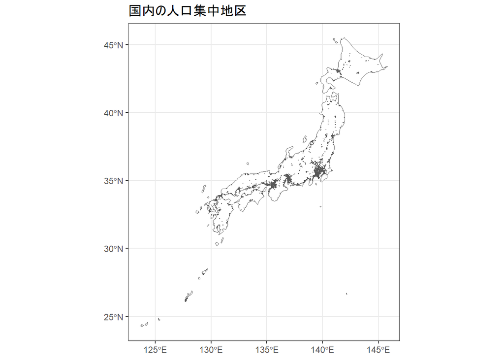

```r
ggplot()+
  geom_sf(data=Japan_map, fill="white")+
  geom_sf(data=DID_map)+
  ggtitle("国内の人口集中地区")+
  theme_bw()
```

**人口密度の計算**

- 人口集中地区内の人口（`A16_005`，単位：人）を面積（`A16_006`，単位：㎢）で割り，人口密度（`pop_den`）を計算．

```r
DID_map %>%
  mutate(pop_den=A16_005/A16_006) ->
  DID_map
```

**コロプレスマップによる人口密度分布の可視化**

ポリゴンが相対的に小さいときに，ポリゴンの枠内を用いて色分けしても識別不能（枠の黒い線の方が目立つ）．この場合，ポリゴンの枠も色を付けることが考える．

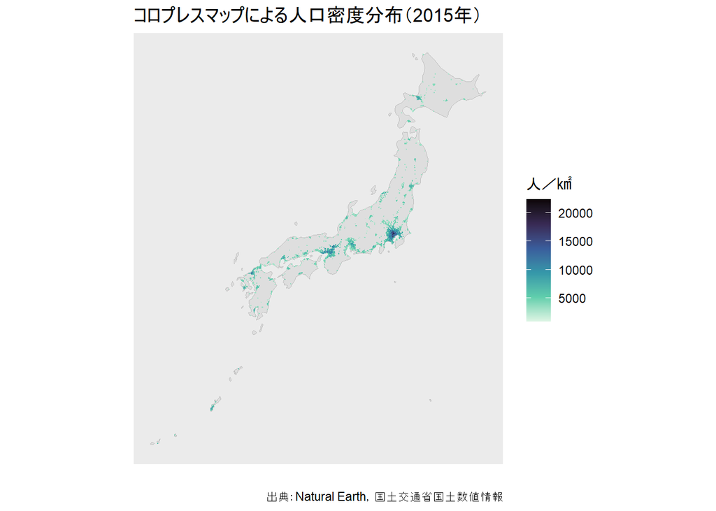

```r
ggplot()+
  geom_sf(data=Japan_map, fill="gray",
          alpha=0.3, color="gray")+
  geom_sf(data=DID_map,
          aes(fill=pop_den, color=pop_den),
          linewidth=0.01)+
  scale_fill_viridis_c(option="G", direction=-1)+
  scale_color_viridis_c(option="G", direction=-1)+
  labs(fill="人／㎢", color="人／㎢",
       x="", y="",
       caption="出典：Natural Earth，国土交通省国土数値情報")+
  ggtitle("コロプレスマップによる人口密度分布（2015年）")+
  coord_sf(datum=NA)+
  theme(legend.position.inside=c(0.85, 0.2),
        legend.background=element_rect(fill=NA, color=NA))
```

# 3 バブルマップ作成準備

**重心の計算と緯度経度の抜き出し**

ポリゴンが小さい場合，地図はまるでポイントデータを色分けしたように見える．そこで，ポイントデータの大小を目立たせる方法であるバブルマップを活用．

- ポリゴンの[重心](https://ja.wikipedia.org/wiki/%E9%87%8D%E5%BF%83)（ポイント）を抜き出し，ポイント（バブル）の色，大きさ，透過度で人口密度の高さを表現．
  - `DID_map`を`WGS84`に投影していることに伴い，重心の計算の際 にエラーメッセージが出現し，先に進めなくなる．
  - [st_make_valid failing to make geometries valid #1732](https://github.com/r-spatial/sf/issues/1732)（アクセス日：2022-08-21）に解決方法が掲載．
  - [`S2`](https://s2geometry.io/)：球状のジオメトリが問題の模様．
    - `warning`が出るが，正しく重心は計算される．エラーを回避するには，`DID_map`の`crs`オプションを外せば良い（この場合，`crs`はJGD2011）が，オプションを外すと，`japan_map`との併用の際に，別のエラー発生．

```r
#球体無視，平面描写
sf_use_s2(FALSE)

#重心の計算
DID_map %>%
  mutate(centroid=st_centroid(geometry),
         x=st_coordinates(centroid)[, 1],
         y=st_coordinates(centroid)[, 2]) ->
  DID_map
```

**人口密度の順番変更**

バブルが重なり合うため，人口密度が高いバブルが地図の上に表れるように順番を変更（`arrange`）．

```r
DID_map %>%
  arrange(pop_den) ->
  DID_map
```

**奄美群島と沖縄県を切り離した日本地図の作成**

- 地図名は`Base map`とする（`Base_map <-`）．
- `coord_sf()`を用いて，地図の範囲を東経`128`°から`148`°，北緯`30`°から`45`°に制限．
  - この作業に伴い，日本地図の右下（南東）方向に位置する小笠原諸島も削除されるが，小笠原諸島に人口集中地区は存在しないため，再び地図に示さないことにする．
- バブルマップの作成（色合い，背景，凡例の位置など）については[Bubble map with ggplot2](https://r-graph-gallery.com/330-bubble-map-with-ggplot2.html)（アクセス日：2022-08-21）に依存．`Base_map`と名付ける．
  - バブルマップを表現するポイントデータは`geom_point()`の`aes()`に示される．ここでは人口密度（`pop_den`）を色（`color`），大きさ（`size`）だけでなく，透過度（`alpha`）でも表現する．
  - `scale_color_viridis_c()`で色分け，`scale_size_continuous()`で描写する大きさの範囲，`scale_alpha_continuous()`で描写する透過度の範囲を指示．
    - 大きさは人口密度が高いほど，大きくなり，透過度は人口密度が高いほど，不透明になるように指示．

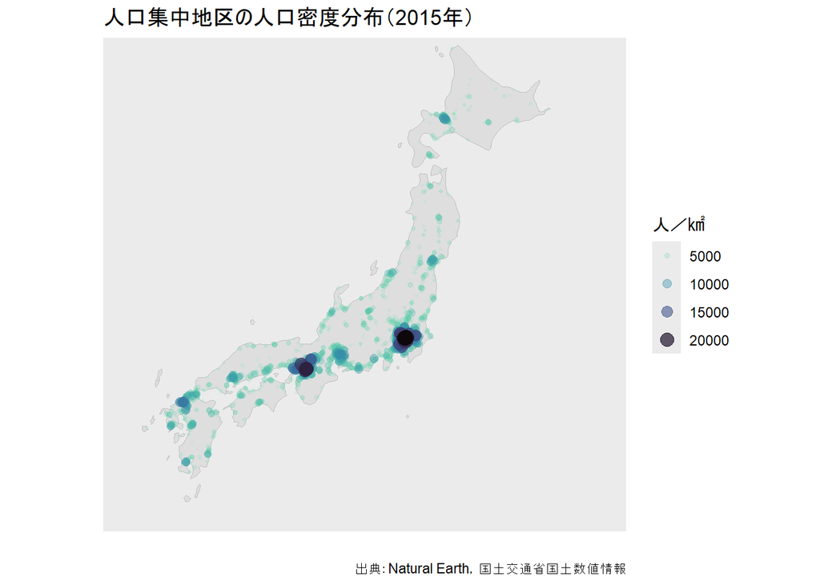

```r
Base_map <-
  ggplot()+
  geom_sf(data=Japan_map, fill="gray",
          alpha=0.3, color="gray")+
  geom_point(data=DID_map,
             aes(x=x, y=y, color=pop_den,
                 size=pop_den, alpha=pop_den))+
  scale_color_viridis_c(option="G", direction=-1,
                        guide="legend")+
  scale_size_continuous(range=c(-1, 4))+
  scale_alpha_continuous(range=c(0.1, 0.8))+
  labs(color="人／㎢", size="人／㎢", alpha="人／㎢",
       x="", y="",
       caption="出典：Natural Earth，国土交通省国土数値情報")+
  ggtitle("人口集中地区の人口密度分布（2015年）")+
  coord_sf(xlim=c(128, 148), ylim=c(30, 45), datum=NA)+
  theme(legend.position.inside=c(0.85, 0.2),
        legend.background=element_rect(fill=NA, color=NA))

#Base_mapのプロット
Base_map
```

**区切り線**

あらかじめ，奄美群島・沖縄県の区切り線を作成しておく．

- 位置を区切る線を引く（`annotate()`）．
  - 線の出発点（座標）と終点を示し，線の色（`color`）や太さ（`size`）を指定．
  - 地図名は`-> Base_map`のまま．

```r
Base_map +
  annotate("segment", x=128.5, xend=132.2,
           y=38.5, yend=38.5,
           color="gray", linewidth=1)+
  annotate("segment", x=132.2, xend=136.7,
           y=38.5, yend=43.2,
           color="gray", linewidth=1) ->
  Base_map
```

**奄美群島と沖縄県の地図の作成**

- 地図名は`Amami_Okinawa_map`とする．
- `coord_sf()`を用いて，地図の範囲を東経`123.5`°から`129.5`°，北緯`23.5`°から`28.5`°に制限．
  - 後ほど縮小して，`base_map`に表現するため，奄美群島と沖縄県のポリゴンの枠線（`geom_sf()`の`size`）が細くならように変更．
    - `legend.position="none"`：凡例削除．

```r
Amami_Okinawa_map <-
  ggplot()+
  geom_sf(data=Japan_map, fill="gray", alpha=0.3,
          color="gray", linewidth=0.8)+
  geom_point(data=DID_map,
             aes(x=x, y=y, color=pop_den,
                 size=pop_den, alpha=pop_den))+
  scale_color_viridis_c(option="G", direction=-1,
                        guide="legend")+
  scale_size_continuous(range=c(-1, 4))+
  scale_alpha_continuous(range=c(0.1, 0.8))+
  labs(color="人／㎢", size="人／㎢", alpha="人／㎢",
       x="", y="")+
  coord_sf(xlim= c(123.5, 129.5), ylim=c(23.5, 28.5),
           datum=NA)+
  theme(legend.position="none")
```

**背景の無色化**

ここでは，`Amami_Okinawa_map`の背景を無色にして，`Base_map`上に表現したい．

- `theme()`：図の体裁を変更する際に利用．
  - `fill="transparent"`：背景の枠内透明．
  - `color=NA`：背景の枠を削除．
  - 主グリッド（`grid.major`）と補助グリッド（`grind.minor`）のの線（`line`）の色を削除（`color=NA`）．
  - 上記Rコードで枠内は透明になるが，余白を含む背景は白いまま．すなわち白い背景（①）に，透明な背景（②）の地図を作成していることになる．
  - ①も無色にするため，`plot.background`で無色にするように指示．
  - 背景の無色化に関するRコードは，[ggplot2で透明な背景にする方法](https://qiita.com/kazutan/items/615415e9b9c74123a822)（アクセス日：2022-08-21）を参考にした．

```r
Amami_Okinawa_map +
  theme(
  panel.background=element_rect(fill="transparent", color=NA),
  panel.grid.major=element_line(color=NA),
  panel.grid.minor=element_line(color=NA),
  plot.background=element_rect(fill="transparent", color=NA)
  ) ->
  Amami_Okinawa_map
```

**奄美群島・沖縄県可視化**

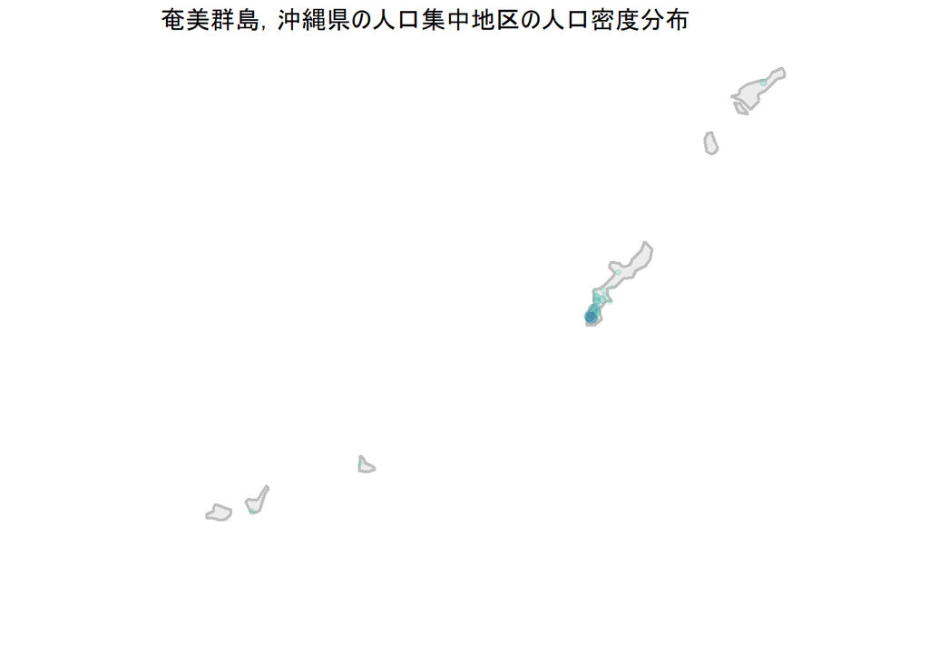

```r
#Amami_Okinawa_mapのプロット
Amami_Okinawa_map +
  ggtitle("奄美群島，沖縄県の人口集中地区の人口密度分布")
```

**地図の保存**

PNGで保存．

- 拡張子を`.png`にすることでPNGで保存される．
  - 地図は，特に指定がなければ，同じフォルダに保存される．
  - 背景（`bg`）が無色（`transparent`）であることを認識させる．

```r
ggsave("Amami_Okinawa_map.png",
       Amami_Okinawa_map, bg="transparent")
```

# 4 バブルマップによる人口密度分布の可視化

**完成図形**

`Base_map`上に地図画像`Amami_Okinawa_map.png`を貼り付ける．

- `set_null_device("png")`：問題を引き起こさせないため．
- `ggdraw()`：下地になる図の指示．
  - `draw_image()`：貼り付ける図の指示．
    - 倍率`scale`，貼り付け位置（水平方向（`halign`），垂直方向（`valign`））の指定．

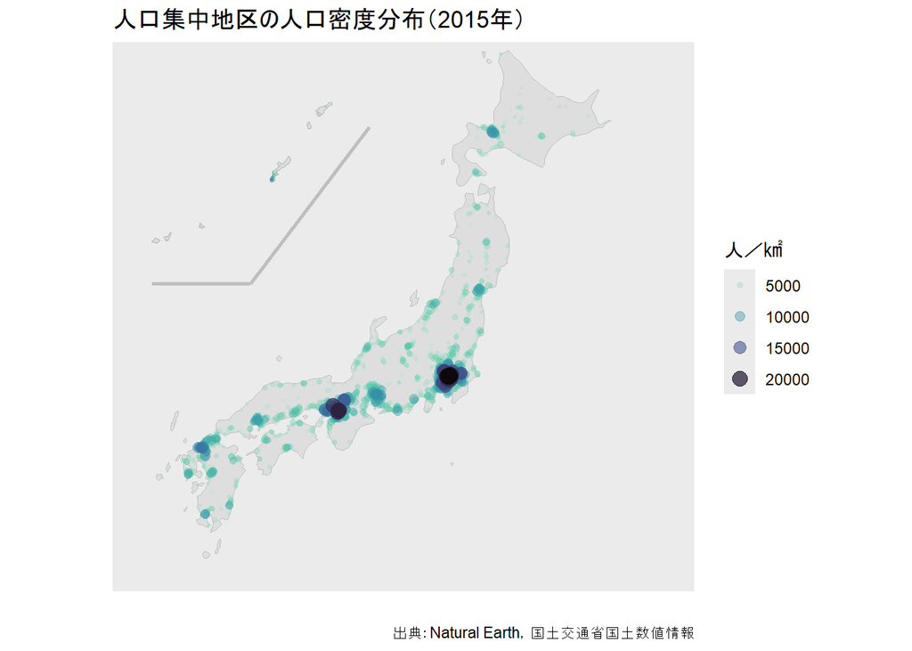

```r
set_null_device("png")

#完成図形
ggdraw(Base_map)+
  draw_image("Amami_Okinawa_map.png",
             scale=0.3,
             halign=0.15, valign=0.8)
```

**参考ウェブサイト**

- [Bubble map with ggplot2](https://r-graph-gallery.com/330-bubble-map-with-ggplot2.html) – [the R Graph Gallery](https://r-graph-gallery.com/)（アクセス日：2022-08-21）
- [ggplot2で透明な背景にする方法](https://qiita.com/kazutan/items/615415e9b9c74123a822)（アクセス日：2022-08-21）
- **その他**の参考ウェブサイトについては，適宜説明部分にリンク先を示す．

**参考文献**

- Brakman, S., H. Garretsen, and C. van Marrewijk (2019), [*An Introduction to Geographical and Urban Economics: A Spiky World*](https://www.cambridge.org/highereducation/books/an-introduction-to-geographical-and-urban-economics/CB3FD3AE2CC95ADF65D7FB15397C7C97#overview) (3rd ed.), Cambridge University Press.

**Rによる地理空間データの可視化**

- チュートリアル[ホーム](https://shinichiro-iwata.github.io/geospatial-data-visualization/)
[^1]: 国内の都市人口をバブルマップで表現する方法はBrakman et al.（2019）のテキスト18頁，図1.6参照．
[^2]: 誤：122,113人，正：12,213人．[三重の統計情報：みえDATABOX](https://www.pref.mie.lg.jp/DATABOX/60323003738-01.htm)，平成27年国勢調査[結果の概要](https://www.pref.mie.lg.jp/common/content/000702204.pdf)（アクセス日：2022-08-21）で確認．